# A jövedelemre ható tényezők vizsgálata

Regresszió- és varianciaelemzés a B_01.sav adatállományon

# 1 A feladat célja

A feladatban azt vizsgálom meg, hogy a `B_01.sav` adatállományban szereplő gyermekkori életkörülmények közül melyek mutatnak kapcsolatot a főállásból származó havi nettó jövedelemmel.

A vizsgált változók:

- `fojov`: főállásból származó havi nettó jövedelem, ezer Ft-ban,
- `gyvillan`: volt-e villany a gyermekkori lakásban (0 = nem volt, 1 = volt),
- `gyhanyfo`: hány fő élt a gyermekkori háztartásban,
- `gyfutlen`: aludt-e valaki fűtetlen szobában (0 = nem, 1 = igen),
- `gyehes2`: éhezett-e gyermekkorában (0 = nem, 1 = igen).

A `sorsz` változó csak azonosító, ezért azt nem használom magyarázó változóként.

A számszerű magyarázó változót regresszióban, a kétkategóriás változókat pedig regresszióban és varianciaanalízissel is megvizsgálom. A végén megnézem a magyarázó változók egymás közötti korrelációját is.

# 2 Csomagok és adatok beolvasása

```r
library(foreign)
library(knitr)
library(car)
library(gvlma)
```

```r
data <- read.spss("B_01.sav", to.data.frame = TRUE, use.value.labels = FALSE)

# A további kód egyszerűbb, ha kisbetűs változóneveket használunk.
names(data) <- tolower(names(data))

# A 999 a jövedelemnél "nem tudja", ezért hiányzó értékként kezeljük.
data$fojov[data$fojov == 999] <- NA

# Csak az elemzéshez szükséges változók maradnak.
elemzes <- data[, c("fojov", "gyvillan", "gyhanyfo", "gyfutlen", "gyehes2")]
elemzes <- elemzes[complete.cases(elemzes), ]

nrow(elemzes)
```

```
## [1] 2865
```

Az elemzésben **2865 teljes megfigyelés** használható.

A varianciaanalízishez a 0/1 kódolású változókból faktorváltozókat készítek.

```r
elemzes$gyvillan_f <- factor(elemzes$gyvillan,
                             levels = c(0, 1),
                             labels = c("nem volt", "volt"))

elemzes$gyfutlen_f <- factor(elemzes$gyfutlen,
                             levels = c(0, 1),
                             labels = c("nem", "igen"))

elemzes$gyehes2_f <- factor(elemzes$gyehes2,
                            levels = c(0, 1),
                            labels = c("nem", "igen"))
```

# 3 Regresszióelemzés

A többváltozós regresszióban egyszerre szerepeltetem a négy magyarázó változót. A kétkategóriás változók 0/1 kódolásúak, ezért regresszióban is használhatók.

```r
fit <- lm(fojov ~ gyvillan + gyhanyfo + gyfutlen + gyehes2,
          data = elemzes)
summary(fit)
```

```
##
## Call:
## lm(formula = fojov ~ gyvillan + gyhanyfo + gyfutlen + gyehes2,
##     data = elemzes)
##
## Residuals:
##     Min      1Q  Median      3Q     Max
## -12.164  -3.645  -1.052   2.374 138.392
##
## Coefficients:
##             Estimate Std. Error t value Pr(>|t|)
## (Intercept)  10.0174     0.5877  17.044  < 2e-16 ***
## gyvillan      2.7027     0.3780   7.150 1.09e-12 ***
## gyhanyfo     -0.2780     0.0811  -3.427 0.000618 ***
## gyfutlen     -0.4032     0.4939  -0.817 0.414257
## gyehes2      -0.2605     0.3395  -0.767 0.442953
## ---
## Signif. codes:  0 '***' 0.001 '**' 0.01 '*' 0.05 '.' 0.1 ' ' 1
##
## Residual standard error: 8.459 on 2860 degrees of freedom
## Multiple R-squared:  0.03327,    Adjusted R-squared:  0.03192
## F-statistic: 24.61 on 4 and 2860 DF,  p-value: < 2.2e-16
```

A regressziós modell szignifikáns: az F-próba p-értéke 0,05 alatt van. A modell magyarázóképessége ugyanakkor alacsony, az $R^2$ értéke körülbelül **0,033**, vagyis a jövedelem eltéréseinek mintegy 3,3%-át magyarázzák a modellben szereplő változók.

A becsült együtthatók alapján:

- a `gyvillan` együtthatója pozitív és szignifikáns ($\beta \approx 2,70$, $p<0,001$). Azoknál, akiknek a gyermekkori lakásában volt villany, átlagosan magasabb jövedelem figyelhető meg;
- a `gyhanyfo` együtthatója negatív és szignifikáns ($\beta \approx -0,28$, $p\approx0,001$). A nagyobb gyermekkori háztartás kisebb várható jövedelemmel jár együtt;
- a `gyfutlen` együtthatója nem szignifikáns ($p>0,05$);
- a `gyehes2` együtthatója szintén nem szignifikáns ($p>0,05$).

Ez azt jelenti, hogy a többi változó hatása mellett a regressziós modellben elsősorban a gyermekkori villanyellátás és a háztartás létszáma mutat önálló kapcsolatot a jövedelemmel.

# 4 A regresszió feltételeinek vizsgálata

## 4.1 A reziduumok várható értéke

Konstanst tartalmazó lineáris regressziónál a reziduumok átlaga gyakorlatilag nulla.

```r
mean(resid(fit))
```

```
## [1] 5.632502e-16
```

Ez a feltétel teljesül.

## 4.2 Normalitás

A normalitást a regresszió reziduumain Shapiro-Wilk-próbával vizsgálom.

A nullhipotézis szerint a reziduumok normális eloszlást követnek.

```r
shapiro.test(resid(fit))
```

```
##
##  Shapiro-Wilk normality test
##
## data:  resid(fit)
## W = 0.68863, p-value < 2.2e-16
```

A p-érték 0,05 alatt van, ezért a normalitás feltétele **nem teljesül**. A jövedelemadatok erősen jobbra ferdék, és kiugróan magas értékek is előfordulnak.

## 4.3 Szóráshomogenitás

Az órai regressziós vizsgálathoz hasonlóan a `gvlma` csomaggal ellenőrzöm a modell feltételeit.

```r
gvmodel <- gvlma(fit)
summary(gvmodel)
```

```
##
## Call:
## lm(formula = fojov ~ gyvillan + gyhanyfo + gyfutlen + gyehes2,
##     data = elemzes)
##
## Residuals:
##     Min      1Q  Median      3Q     Max
## -12.164  -3.645  -1.052   2.374 138.392
##
## Coefficients:
##             Estimate Std. Error t value Pr(>|t|)
## (Intercept)  10.0174     0.5877  17.044  < 2e-16 ***
## gyvillan      2.7027     0.3780   7.150 1.09e-12 ***
## gyhanyfo     -0.2780     0.0811  -3.427 0.000618 ***
## gyfutlen     -0.4032     0.4939  -0.817 0.414257
## gyehes2      -0.2605     0.3395  -0.767 0.442953
## ---
## Signif. codes:  0 '***' 0.001 '**' 0.01 '*' 0.05 '.' 0.1 ' ' 1
##
## Residual standard error: 8.459 on 2860 degrees of freedom
## Multiple R-squared:  0.03327,    Adjusted R-squared:  0.03192
## F-statistic: 24.61 on 4 and 2860 DF,  p-value: < 2.2e-16
##
##
## ASSESSMENT OF THE LINEAR MODEL ASSUMPTIONS
## USING THE GLOBAL TEST ON 4 DEGREES-OF-FREEDOM:
## Level of Significance =  0.05
##
## Call:
##  gvlma(x = fit)
##
##                        Value p-value                   Decision
## Global Stat        4.852e+05 0.00000 Assumptions NOT satisfied!
## Skewness           1.413e+04 0.00000 Assumptions NOT satisfied!
## Kurtosis           4.710e+05 0.00000 Assumptions NOT satisfied!
## Link Function      3.261e+00 0.07093    Assumptions acceptable.
## Heteroscedasticity 5.352e+00 0.02069 Assumptions NOT satisfied!
```

A heteroszkedaszticitásra vonatkozó eredmény alapján a hibatagok varianciája nem tekinthető állandónak, ezért a szóráshomogenitás feltétele **nem teljesül megfelelően**.

## 4.4 Multikollinearitás

A magyarázó változók közötti túl erős kapcsolatot VIF-mutatóval vizsgálom.

```r
vif(fit)
```

```
## gyvillan gyhanyfo gyfutlen  gyehes2
## 1.154731 1.146404 1.070196 1.145590
```

```r
sqrt(vif(fit)) > 2
```

```
## gyvillan gyhanyfo gyfutlen  gyehes2
##    FALSE    FALSE    FALSE    FALSE
```

A VIF-értékek mind alacsonyak, körülbelül 1,1 körüliek. Ez alapján a multikollinearitás hatása **elhanyagolható**.

## 4.5 Diagnosztikai ábrák

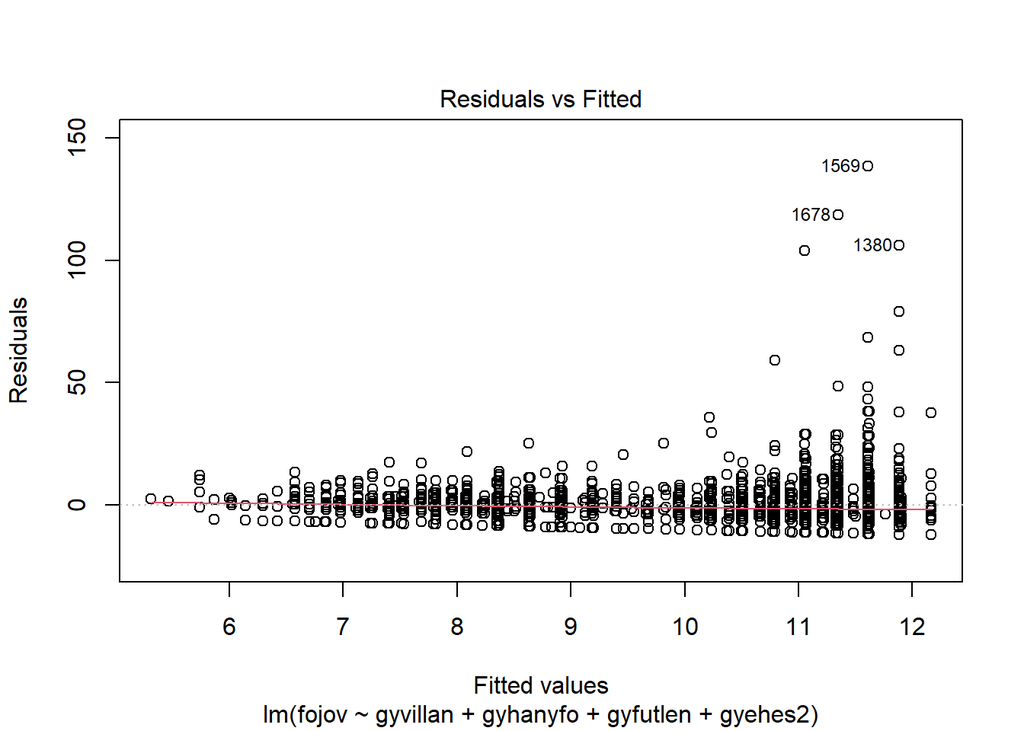

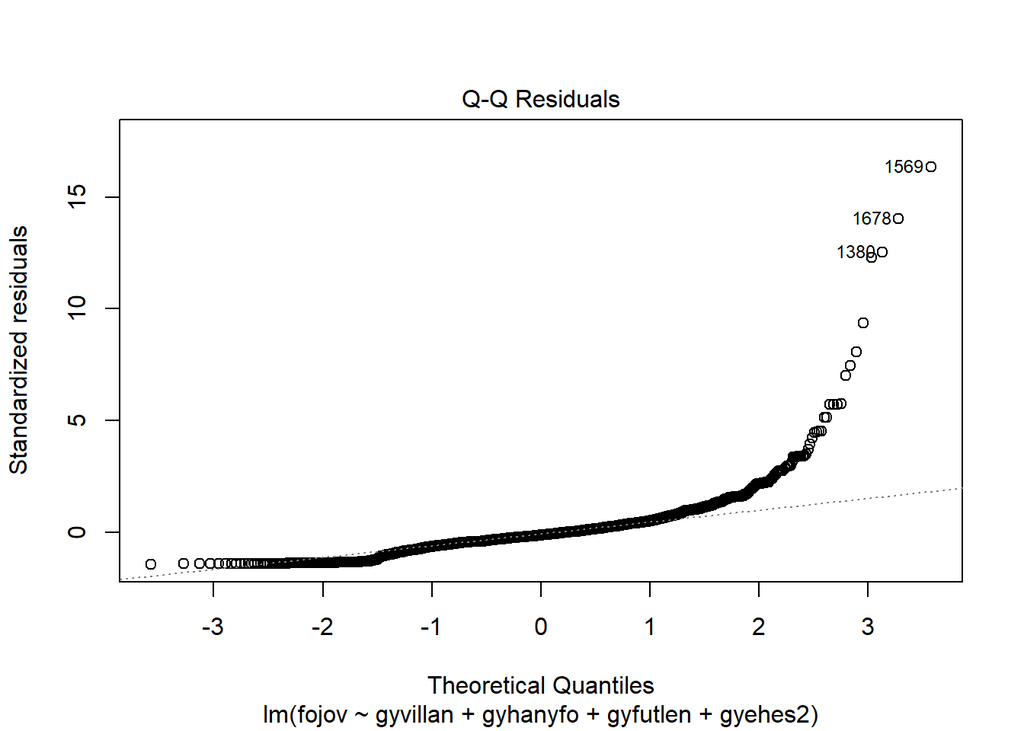

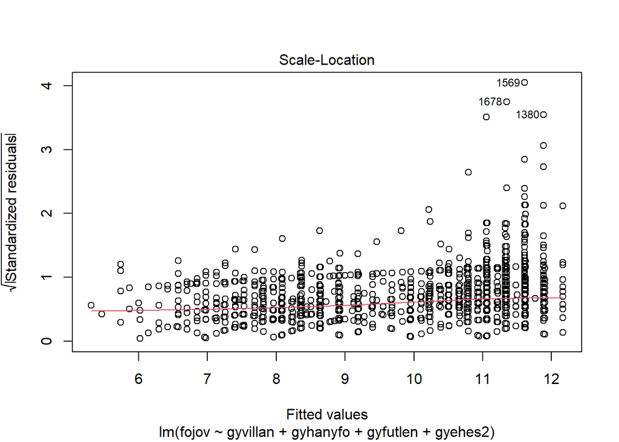

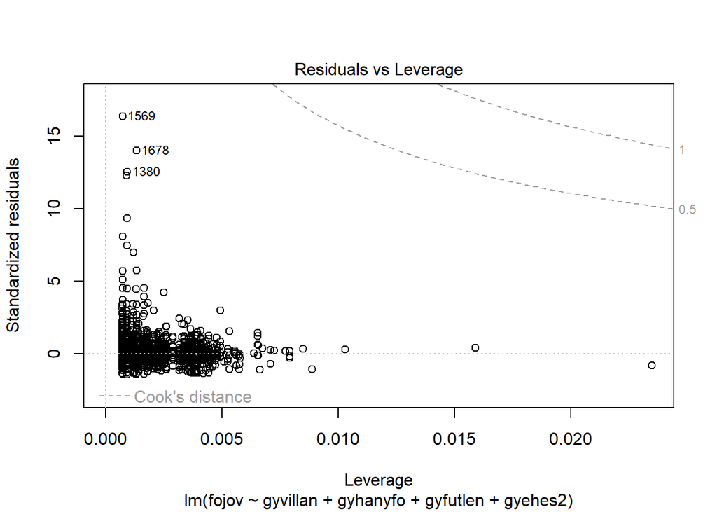

```r
plot(fit)
```

Az ábrák is azt mutatják, hogy a reziduumok eloszlása nem normális, és néhány kiugró megfigyelés is található. Ez összhangban van a formális vizsgálatok eredményével.

Összességében tehát a regressziós modell normalitási és szóráshomogenitási feltétele nem teljesül, a multikollinearitás viszont nem jelent problémát. Emiatt a regressziós eredményeket óvatosan kell értelmezni.

# 5 Varianciaanalízis

A három kétkategóriás gyermekkori életkörülmény esetében egyutas varianciaanalízissel is megvizsgálom, hogy eltér-e a jövedelem a csoportok között.

## 5.1 Villany a gyermekkori lakásban

```r
aggregate(fojov ~ gyvillan_f, data = elemzes, FUN = mean)
```

```
##   gyvillan_f     fojov
## 1   nem volt  8.026119
## 2       volt 11.221252
```

```r
anova_villany <- aov(fojov ~ gyvillan_f, data = elemzes)
summary(anova_villany)
```

```
##               Df Sum Sq Mean Sq F value Pr(>F)
## gyvillan_f     1   5905    5905   82.14 <2e-16 ***
## Residuals   2863 205804      72
## ---
## Signif. codes:  0 '***' 0.001 '**' 0.01 '*' 0.05 '.' 0.1 ' ' 1
```

A villany nélküli gyermekkori lakásban élők átlagos jövedelme körülbelül **8,03 ezer Ft**, míg azoké, akiknél volt villany, körülbelül **11,22 ezer Ft**. A különbség szignifikáns ($p<0,001$).

## 5.2 Fűtetlen szobában alvás

```r
aggregate(fojov ~ gyfutlen_f, data = elemzes, FUN = mean)
```

```
##   gyfutlen_f     fojov
## 1        nem 10.509178
## 2       igen  9.036212
```

```r
anova_futetlen <- aov(fojov ~ gyfutlen_f, data = elemzes)
summary(anova_futetlen)
```

```
##               Df Sum Sq Mean Sq F value  Pr(>F)
## gyfutlen_f     1    681   681.3   9.243 0.00239 **
## Residuals   2863 211027    73.7
## ---
## Signif. codes:  0 '***' 0.001 '**' 0.01 '*' 0.05 '.' 0.1 ' ' 1
```

Azok átlagos jövedelme, akik gyermekkorukban nem aludtak fűtetlen szobában, körülbelül **10,51 ezer Ft**, míg az igen választ adóknál körülbelül **9,04 ezer Ft**. A különbség szignifikáns ($p<0,01$).

## 5.3 Gyermekkori éhezés

```r
aggregate(fojov ~ gyehes2_f, data = elemzes, FUN = mean)
```

```
##   gyehes2_f     fojov
## 1       nem 10.920798
## 2      igen  9.618902
```

```r
anova_ehezes <- aov(fojov ~ gyehes2_f, data = elemzes)
summary(anova_ehezes)
```

```
##               Df Sum Sq Mean Sq F value   Pr(>F)
## gyehes2_f      1   1205  1205.4   16.39 5.28e-05 ***
## Residuals   2863 210503    73.5
## ---
## Signif. codes:  0 '***' 0.001 '**' 0.01 '*' 0.05 '.' 0.1 ' ' 1
```

Azok átlagos jövedelme, akik nem éheztek gyermekkorukban, körülbelül **10,92 ezer Ft**, az éhezésről beszámolóknál pedig körülbelül **9,62 ezer Ft**. A különbség szintén szignifikáns ($p<0,001$).

# 6 A varianciaanalízis feltételei

A varianciaanalízisnél a normalitást a modellek reziduumain vizsgálom.

```r
shapiro.test(resid(anova_villany))
```

```
##
##  Shapiro-Wilk normality test
##
## data:  resid(anova_villany)
## W = 0.68405, p-value < 2.2e-16
```

```r
shapiro.test(resid(anova_futetlen))
```

```
##
##  Shapiro-Wilk normality test
##
## data:  resid(anova_futetlen)
## W = 0.67854, p-value < 2.2e-16
```

```r
shapiro.test(resid(anova_ehezes))
```

```
##
##  Shapiro-Wilk normality test
##
## data:  resid(anova_ehezes)
## W = 0.68035, p-value < 2.2e-16
```

Mindhárom esetben 0,05 alatti p-értéket kapunk, ezért a normalitás feltétele **egyik varianciaanalízisnél sem teljesül**.

A varianciák homogenitását Levene-próbával vizsgálom.

```r
leveneTest(fojov ~ gyvillan_f, data = elemzes)
```

```
## Levene's Test for Homogeneity of Variance (center = median)
##         Df F value    Pr(>F)
## group    1  51.765 7.952e-13 ***
##       2863
## ---
## Signif. codes:  0 '***' 0.001 '**' 0.01 '*' 0.05 '.' 0.1 ' ' 1
```

```r
leveneTest(fojov ~ gyfutlen_f, data = elemzes)
```

```
## Levene's Test for Homogeneity of Variance (center = median)
##         Df F value   Pr(>F)
## group    1  9.0895 0.002593 **
##       2863
## ---
## Signif. codes:  0 '***' 0.001 '**' 0.01 '*' 0.05 '.' 0.1 ' ' 1
```

```r
leveneTest(fojov ~ gyehes2_f, data = elemzes)
```

```
## Levene's Test for Homogeneity of Variance (center = median)
##         Df F value    Pr(>F)
## group    1  12.459 0.0004227 ***
##       2863
## ---
## Signif. codes:  0 '***' 0.001 '**' 0.01 '*' 0.05 '.' 0.1 ' ' 1
```

A Levene-próbák p-értékei 0,05 alatt vannak, ezért a csoportok szórásai sem tekinthetők homogénnek. A varianciaanalízis két fontos alkalmazási feltétele tehát sérül.

A varianciaanalízis eredményeit emiatt szintén óvatosan kell értelmezni.

# 7 A magyarázó változók korrelációja

Mivel a magyarázó változók között kétkategóriás és diszkrét változók is vannak, az órai korrelációs vizsgálathoz hasonlóan Kendall-féle rangkorrelációt használok.

```r
magyarazok <- elemzes[, c("gyvillan", "gyhanyfo", "gyfutlen", "gyehes2")]
round(cor(magyarazok, method = "kendall"), 3)
```

```
##          gyvillan gyhanyfo gyfutlen gyehes2
## gyvillan    1.000   -0.240   -0.181  -0.282
## gyhanyfo   -0.240    1.000    0.156   0.230
## gyfutlen   -0.181    0.156    1.000   0.179
## gyehes2    -0.282    0.230    0.179   1.000
```

A kapcsolat szignifikanciáját páronként is ellenőrzöm.

```r
valtozok <- names(magyarazok)
parok <- combn(valtozok, 2)

for (i in 1:ncol(parok)) {
  x <- magyarazok[[parok[1, i]]]
  y <- magyarazok[[parok[2, i]]]
  teszt <- cor.test(x, y, method = "kendall", exact = FALSE)
  cat(parok[1, i], "-", parok[2, i],
      ": tau =", round(unname(teszt$estimate), 3),
      ", p =", format.pval(teszt$p.value, digits = 3), "\n")
}
```

```
## gyvillan - gyhanyfo : tau = -0.24 , p = <2e-16
## gyvillan - gyfutlen : tau = -0.181 , p = <2e-16
## gyvillan - gyehes2 : tau = -0.282 , p = <2e-16
## gyhanyfo - gyfutlen : tau = 0.156 , p = <2e-16
## gyhanyfo - gyehes2 : tau = 0.23 , p = <2e-16
## gyfutlen - gyehes2 : tau = 0.179 , p = <2e-16
```

A nagy elemszám miatt valamennyi változópár között statisztikailag kimutatható kapcsolat van, de ezek erőssége nem nagy.

A legerősebb kapcsolatok:

- `gyvillan` és `gyehes2`: $\tau\approx-0,282$;
- `gyvillan` és `gyhanyfo`: $\tau\approx-0,240$;
- `gyhanyfo` és `gyehes2`: $\tau\approx0,230$.

A negatív előjel azt jelenti, hogy ahol jobb volt a gyermekkori lakás villanyellátása, ott ritkább volt az éhezés és általában kisebb volt a háztartás létszáma. A többi kapcsolat is gyenge. Ez összhangban van a regresszió VIF-eredményével: a magyarázó változók között van kapcsolat, de nem olyan erős, hogy komoly multikollinearitást okozzon.

# 8 A regressziós és varianciaanalízis eredmények összehasonlítása

A két módszer nem teljesen ugyanazt vizsgálja. A varianciaanalízisek külön-külön hasonlítják össze a csoportok átlagjövedelmét, míg a többváltozós regresszióban a magyarázó változók egyszerre szerepelnek.

A varianciaanalízis szerint mindhárom kétkategóriás változónál szignifikáns jövedelmi különbség van. A regresszióban azonban a többi tényező hatását is figyelembe véve csak a `gyvillan` és a `gyhanyfo` marad szignifikáns. A `gyfutlen` és a `gyehes2` önálló regressziós hatása már nem mutatható ki.

Ennek egyik oka az lehet, hogy a gyermekkori hátrányokat mérő változók egymással is kapcsolatban állnak. Például az éhezés, a villany hiánya, a nagyobb háztartás és a fűtetlen szobában alvás részben ugyanannak a kedvezőtlenebb gyermekkori élethelyzetnek különböző jellemzői.

A legfontosabb következtetés, hogy a vizsgált tényezők közül a **gyermekkori villanyellátás** és a **gyermekkori háztartás létszáma** mutat a többváltozós regresszióban is önálló kapcsolatot a későbbi jövedelemmel. Ugyanakkor sem a regresszió, sem a varianciaanalízis alkalmazási feltételei nem teljesülnek maradéktalanul, ezért az eredmények értelmezésénél ezt figyelembe kell venni.